# SP_27__GL

## Групове заняття 15

### Тема 2: Обробка масивів даних. Машинне навчання з учителем

### Заняття 27: Візуалізація даних

### Результати заняття

*(слухач зможе)*

1. Застосувати знання бібліотек `matplotlib`, `seborn` для відображення результатів розрахунків.
2. Застосувати знання бібліотек `matplotlib`, `seborn` для аналізу масиву даних.

**НАВЧАЛЬНИЙ ЧАС**: 2 години.

**Навчальна література:**

1. The Python Tutorial [Електронний ресурс] – Режим доступу до ресурсу: https://docs.python.org/3/tutorial/index.html.
2. Pandas. Working with text data [Електронний ресурс] – Режим доступу до ресурсу: https://pandas.pydata.org/docs/user_guide/text.html
3. Matplotlib documentation [Електронний ресурс] – Режим доступу до ресурсу: https://matplotlib.org/stable/index.html
4. Seaborn. User guide and tutorial [Електронний ресурс] – Режим доступу до ресурсу: https://seaborn.pydata.org/tutorial.html

### ПЛАН ЗАНЯТТЯ

| № з/п | Навчальні питання | Час, хв |
| --- | --- | --- |
| 1 | **ВСТУПНА ЧАСТИНА** | 5 |
| 2 | **ОСНОВНА ЧАСТИНА** | 80 |
| 2.1 | Matplotlib. Основи застосування | 40 |
| 2.2 | Seaborn. Основи застосування | 40 |
| 3 | **ЗАКЛЮЧНА ЧАСТИНА** | 5 |

### Навчальне питання 1. Matplotlib. Основи застосування

*Теорія - 20 хв, практика - 20 хв*

Ознайомлення з даними, перед початком роботи з ними, є важливим етапом, оскільки дозволяють оцінити та вибрати стратегію подальших дій. Однією із найбільш широко застосовуваних бібліотек для візуалізації даних є `matplotlib`. Для початку роботи із `matplotlib` її необхідно встановити

```python
# pip install matplotlib
```

Після встановлення подальше можливе застосування наступне

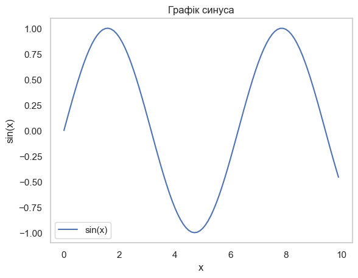

```python
import matplotlib.pyplot as plt
import numpy as np
import pandas as pd

x = np.arange(0, 10, 0.1) # створюємо масив x з кроком 0.1
y = np.sin(x) # обчислюємо y як синус x
# створюємо графік
plt.plot(x, y, label='sin(x)') # відображаємо графік синуса
plt.title('Графік синуса') # заголовок графіка
plt.xlabel('x') # підпис осі x
plt.ylabel('sin(x)') # підпис осі y

plt.legend() # показуємо легенду
plt.grid() # додаємо сітку на графік
plt.savefig('sin_plot.png') # зберігаємо графік у файл

plt.show()
```

Усі методи, які застосовуються для додавання елементів на графік, необхідно писати у одній чарунці.

Для корегування діапазону відображення по вісі **абсцис** та **ординат** можна застосувати методи `.xlim()` `.ylim()`

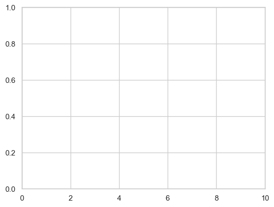

```python
plt.xlim(0, 10) # обмежуємо ось x від 0 до 10
plt.show()
```

Спроба відобразити графік не дає результатів, оскільки є розрив між чарунками (**вище було застереження**). Але тим не менше, вісь `x` відображається від 0 до 10.

> *Практичне завдання 1*

> Розробити код програми, що дозволяє:
> 1. Отримати вираз для обчислення координат гіперболи.
> 2. Відобразити отримані дані на графіку.

Використання зазначених методів в основному дозволяє здійснювати відображення графіків швидко і достатньо просто.

У випадку якщо необхідно врахувати особливості при відображенні даних доцільно використовувати підхід через створення об'єкту `Figure`. Це дозволить більш гнучко підходити до відображення даних.

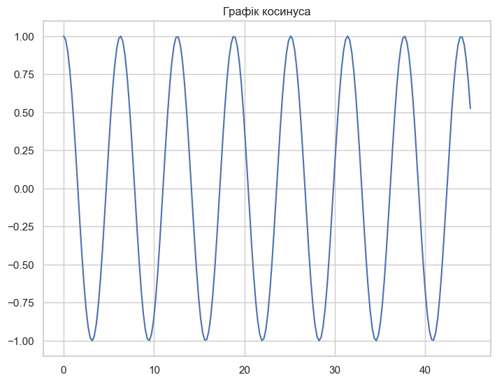

```python
import matplotlib.pyplot as plt
import numpy as np

x = np.linspace(0, 45, num=200)
y = np.cos(x)

fig = plt.figure()

ax1 = fig.add_axes((0.0,0.0,1.0,1.0)) # створюємо осі графіка
ax1.set_title('Графік косинуса') # заголовок графіка
ax1.plot(x,y);
```

Для налаштування відображень на осях та полотні графіка застосовуються наступні методи об'єкту

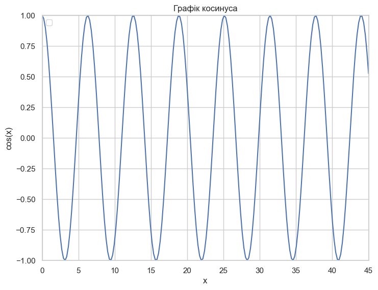

```python
import matplotlib.pyplot as plt
import numpy as np

x = np.linspace(0, 45, num=200)
y = np.cos(x)

fig = plt.figure()

ax1 = fig.add_axes((0,0,1,1))
ax1.set_xlim(0, 45) # обмежуємо ось x від 0 до 45
ax1.set_ylim(-1, 1) # обмежуємо ось y від -1 до 1
ax1.set_xlabel('x') # підпис осі x
ax1.set_ylabel('cos(x)') # підпис осі y
ax1.set_title('Графік косинуса') # заголовок графіка
ax1.legend(['cos(x)']) # легенда графіка

ax1.plot(x,y);
```

За необхідності, є можливість деталізувати фрагмент графіка.

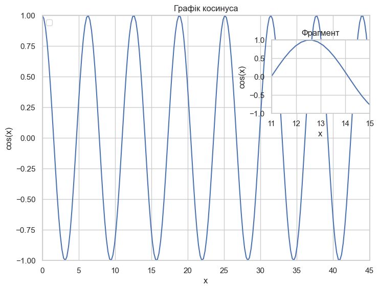

```python
import matplotlib.pyplot as plt
import numpy as np

x = np.linspace(0, 45, num=200)
y = np.cos(x)
fig = plt.figure()
ax1 = fig.add_axes((0,0,1,1))
ax1.set_xlim(0, 45) # обмежуємо ось x від 0 до 45
ax1.set_ylim(-1, 1) # обмежуємо ось y від -1 до 1
ax1.set_xlabel('x') # підпис осі x
ax1.set_ylabel('cos(x)') # підпис осі y
ax1.set_title('Графік косинуса') # заголовок графіка
ax1.legend(['cos(x)']) # легенда графіка
ax1.plot(x,y);

ax2 = fig.add_axes((0.7,0.6,0.3,0.3)) # створюємо нову область для графіка
ax2.set_xlim(11, 15) # обмежуємо ось x від 10 до 25
ax2.set_ylim(-1, 1) # обмежуємо ось y від -1 до 1
ax2.set_xlabel('x') # підпис осі x
ax2.set_ylabel('cos(x)') # підпис осі y
ax2.set_title('Фрагмент') # заголовок графіка
ax2.plot(x,y); # відображаємо графік
```

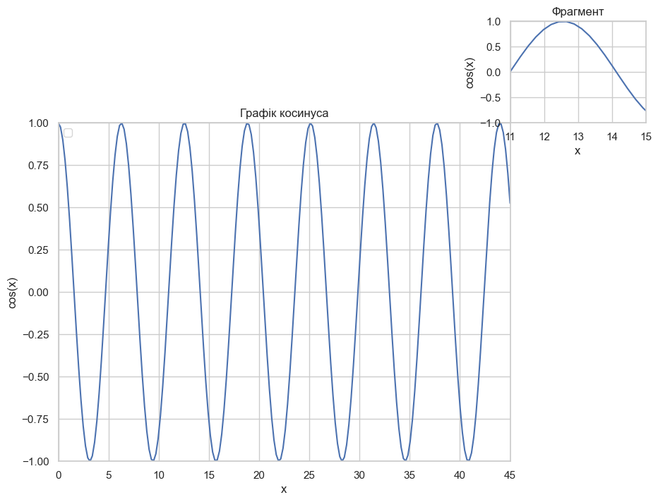

```python
# У такий спосіб фрагмент графіка можна винести за межі основного графіка
# або в окрему область, як показано нижче

import matplotlib.pyplot as plt
import numpy as np

x = np.linspace(0, 45, num=200)
y = np.cos(x)
fig = plt.figure()
ax1 = fig.add_axes((0,0,1,1))
ax1.set_xlim(0, 45) # обмежуємо ось x від 0 до 45
ax1.set_ylim(-1, 1) # обмежуємо ось y від -1 до 1
ax1.set_xlabel('x') # підпис осі x
ax1.set_ylabel('cos(x)') # підпис осі y
ax1.set_title('Графік косинуса') # заголовок графіка
ax1.legend(['cos(x)']) # легенда графіка
ax1.plot(x,y); # відображаємо графік

ax2 = fig.add_axes((1,1,0.3,0.3)) # створюємо нову область для графіка
ax2.set_xlim(11, 15) # обмежуємо ось x від 10 до 25
ax2.set_ylim(-1, 1) # обмежуємо ось y від -1 до 1
ax2.set_xlabel('x') # підпис осі x
ax2.set_ylabel('cos(x)') # підпис осі y
ax2.set_title('Фрагмент') # заголовок графіка
ax2.plot(x,y); # відображаємо графік
```

За допомогою параметрів для об'єкта `Figure`, можливо задати пропорції та якість відображення графіку

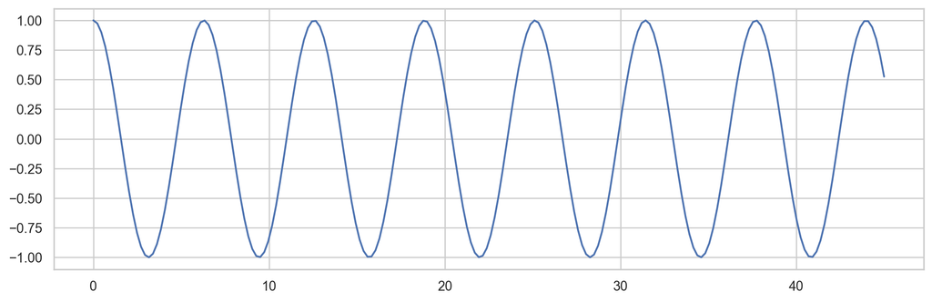

```python
fg = plt.figure(figsize=(10,3), dpi=200) # створюємо нову фігуру
ax = fg.add_axes((0,0,1,1)) # додаємо нову область для графіка
ax.plot(x,y); # відображаємо графік
```

Збереження графіку у файл графічного зображення здійснюється за допомогою методу `.savefig()`, де параметрами передаються назва файлу (шлях до файлу) та необов'язковий 2 параметр - що дозволить забезпечити коректне виведення підписів на вісь `.savefig('name_file.png', bbox_inches='tight')`.

> **Практичне завдання 2**
> 1. Результати аналізу датафрейму щодо налаштування моделі машинного навчання (з попереднього заняття), програмно зберегти у файл.
> 2. Сформувати звітний документ у якому використати даний рисунок для доповіді по розробленій моделі машинного навчання.

### Навчальне питання 2. Seaborn. Основи застосування

*Теорія - 20 хв, практика - 20 хв*

Бібліотека **Seaborn** розроблена на основі **matplotlib** і спрямована на спрощення відображення та візуалізації даних, які опрацьовуються бібліотекою **pandas**. Для встановлення бібліотеки застосовується командний рядок та наступний скрипт

```python
# pip install seaborn
```

Файл для роботи з даними

```python
import seaborn as sns
import matplotlib.pyplot as plt

import pandas as pd
import numpy as np

df = pd.read_csv('dm_office_sales.csv')
df.head()
```

|  | division | level of education | training level | work experience | salary | sales |
| --- | --- | --- | --- | --- | --- | --- |
| 0 | printers | some college | 2 | 6 | 91684 | 372302 |
| 1 | printers | associate's degree | 2 | 10 | 119679 | 495660 |
| 2 | peripherals | high school | 0 | 9 | 82045 | 320453 |
| 3 | office supplies | associate's degree | 2 | 5 | 92949 | 377148 |
| 4 | office supplies | high school | 1 | 5 | 71280 | 312802 |

#### 2.1 **scatterplot**. Правила використання

Щоб відобразити залежність між двома числовими змінними, можна використати діаграму розсіювання `scatterplot`.

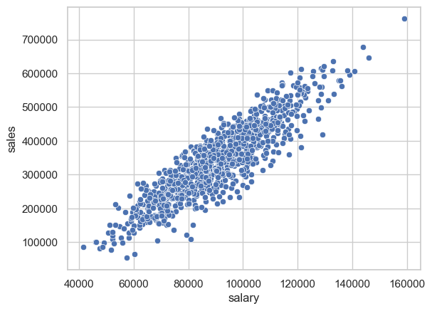

```python
sns.scatterplot(x="salary", y="sales", data=df);
```

Оскільки `seaborn` базується на `matplotlib`, то можна налаштувати графік за допомогою об'єкту `Figure`

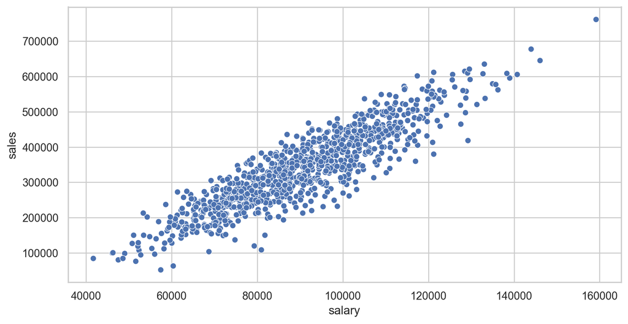

```python
plt.figure(figsize=(10,5), dpi=200)
sns.scatterplot(x="salary", y="sales", data=df);
```

Також можна змінити колір точок на графіку в залежності від значення ще однієї числової змінної. Для цього можна використати параметр `hue`.

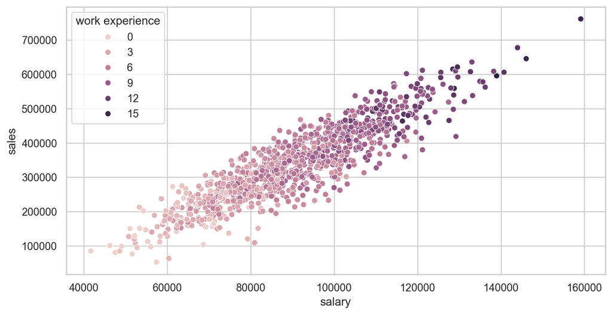

```python
plt.figure(figsize=(10,5), dpi=200)
sns.scatterplot(x="salary", y="sales", hue="work experience", data=df);
# колір точок залежить від віку
```

В залежності від того, який тип стовпця обраний для параметру `hue` (*лінгвістичні змінні чи числові*), значення кольорів буде дискретне або градієнтне

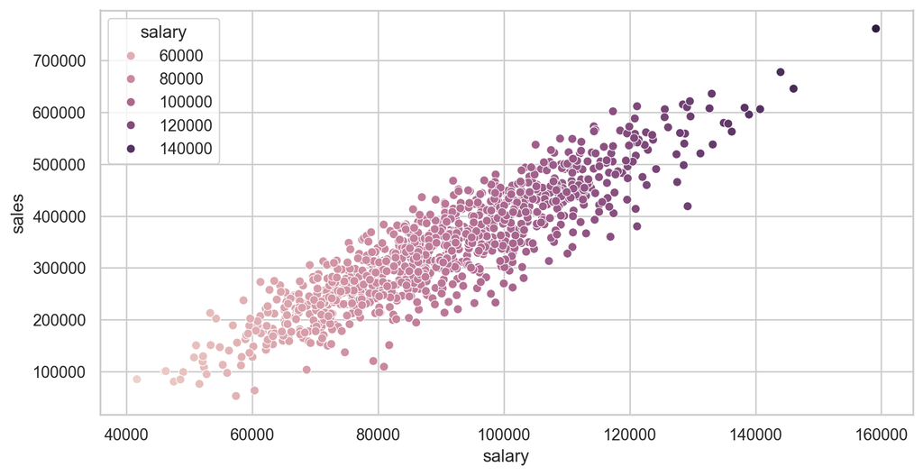

```python
plt.figure(figsize=(10,5), dpi=200)
sns.scatterplot(x="salary", y="sales", hue="salary", data=df);
# колір точок залежить від зарплати
```

У випадку коли необхідно додати ще одну ознаку для відображення на графіку, можливо використати і розмір точок

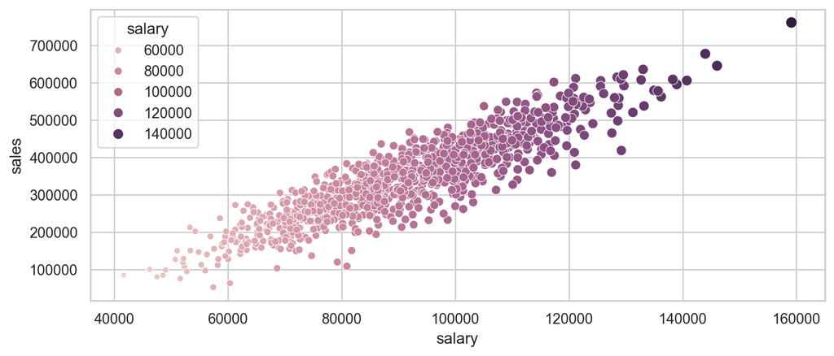

```python
plt.figure(figsize=(10,4), dpi=200)
sns.scatterplot(x="salary", y="sales", hue="salary",
                data=df, size='salary');
# розмір точок залежить від зарплати
```

Якщо є велике згущення точок, то можна використати параметр `alpha` для зменшення прозорості точок

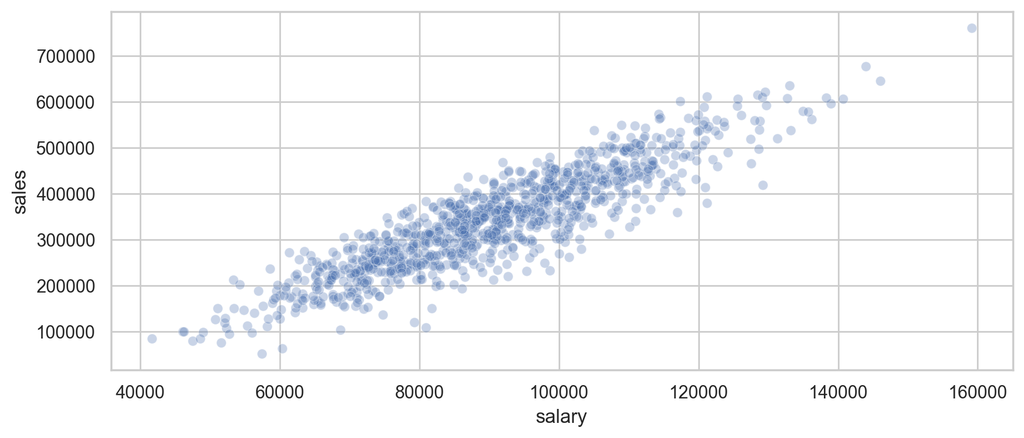

```python
plt.figure(figsize=(10,4), dpi=200)
sns.scatterplot(x="salary", y="sales",  data=df, alpha=0.3);
# прозорість точок 30%
```

Форму відміток можна змінити за допомогою параметра `style`. Це може бути корисно, коли потрібно друкувати у монохромі

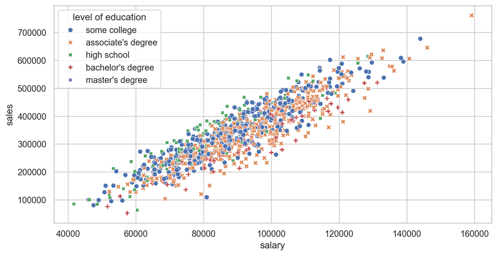

```python
plt.figure(figsize=(10,5), dpi=200)
sns.scatterplot(x="salary", y="sales", hue="level of education",
                style="level of education", data=df);
# форма точок залежить від рівня освіти
```

> *Практичне завдання 2*

> Для наведеної вибірки даних побудувати графіки розподілу для стовпця `sales`

#### 2.2 **rugplot**. Правила використання

Для дослідження розподілу величин, що вивчаються, зручно використовувати інші типи графіків.

```python
import seaborn as sns
import pandas as pd
import numpy as np
import matplotlib.pyplot as plt

df = pd.read_csv('dm_office_sales.csv')
df.head()
```

|  | division | level of education | training level | work experience | salary | sales |
| --- | --- | --- | --- | --- | --- | --- |
| 0 | printers | some college | 2 | 6 | 91684 | 372302 |
| 1 | printers | associate's degree | 2 | 10 | 119679 | 495660 |
| 2 | peripherals | high school | 0 | 9 | 82045 | 320453 |
| 3 | office supplies | associate's degree | 2 | 5 | 92949 | 377148 |
| 4 | office supplies | high school | 1 | 5 | 71280 | 312802 |

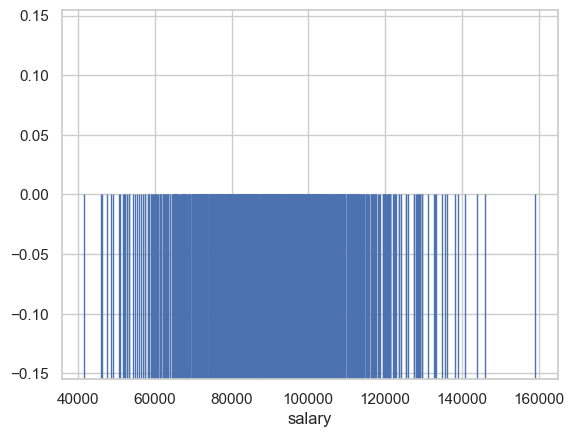

```python
sns.rugplot(x="salary", data=df, height=.5); # відображаємо графік
```

На даному графіку відображено розподіл по заробітній платі. У даному випадку вісь ординат не несе ніякого значення.

> *Практичне завдання 3*

> Для наведеної вибірки даних побудувати графіки розподілу для стовпця `sales`

#### 2.3 **distplot, histplot, kdeplot**. Правила використання

Для формування уявлення про розподіл значень за інтервалами зручно використовувати тип графіків `displot()` `histplot()`

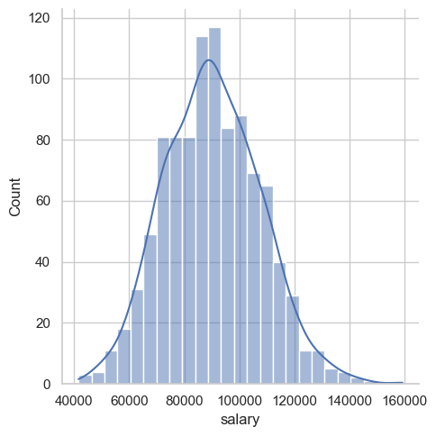

```python
# відображаємо графік з оцінкою щільності
sns.displot(x="salary", data=df, kde=True);
```

Для відображення графіка з оцінкою щільності можна використати параметр `kde=True` або метод `sns.kdeplot()`

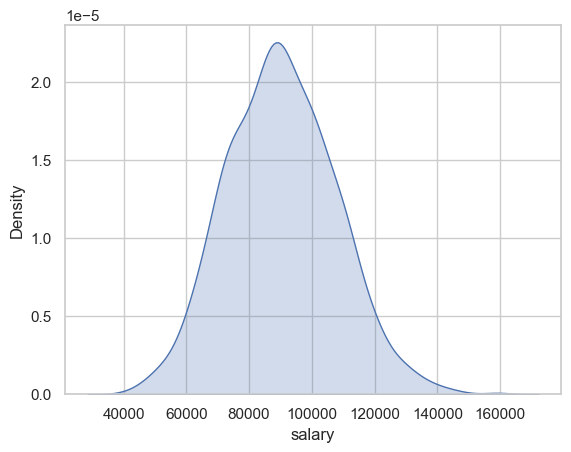

```python
sns.kdeplot(x="salary", data=df, fill=True);
```

Для зміни кількості інтервалів можна використати параметр `bins`

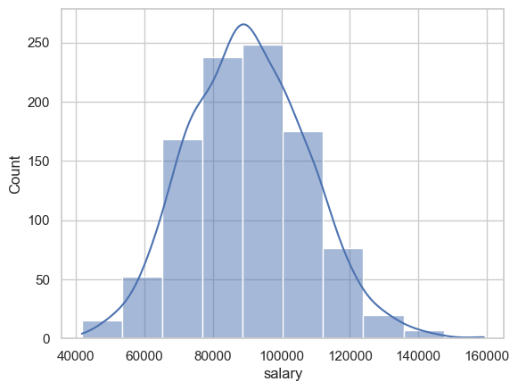

```python
sns.histplot(x="salary", data=df, bins=10, kde=True);
```

Для оцінювання значень можна застосовувати сітку на фоні. А також можна задати стиль для сітки.

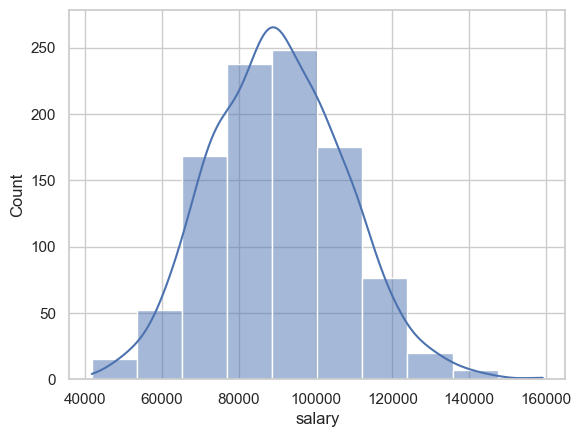

```python
sns.set_theme(style="whitegrid")
sns.histplot(x="salary", data=df, bins=10, kde=True);
```

sns.set_theme(...) - діє на весь поточний документ а не тільки для обраної чарунки

> *Практичне завдання 4*

> Для наведеної вибірки даних побудувати графіки розподілу для стовпця `sales`

#### 2.4 **countplot**. Правила використання

Для більш грунтовного аналізу є можливість вивчення даних для кожної категорії.

Наприклад, для підрахунку кількості унікальних значень у стовпці, застосовуємо метод `value_counts()`

```python
df['division'].value_counts()
```

```
division
office supplies      252
printers             250
peripherals          243
computer hardware    159
computer software     96
Name: count, dtype: int64
```

Графічно вищезазначені значення можна відобразити за допомогою методу `countplot`

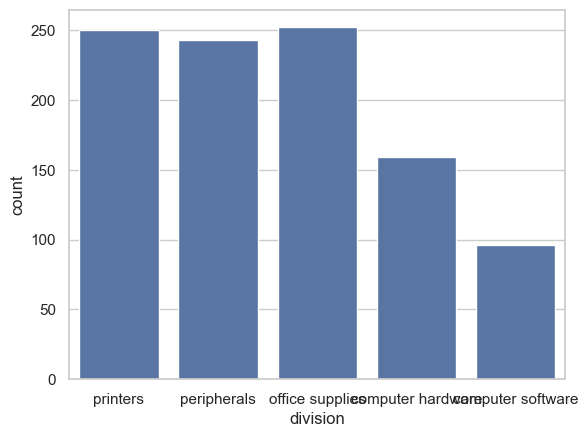

```python
sns.countplot(x="division", data=df);
```

Для зміни кольору графіка можна використати параметр `palette` або параметр `color`

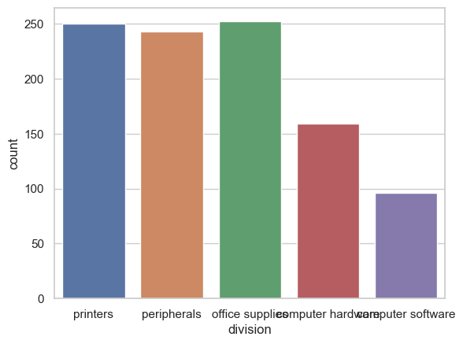

```python
sns.countplot(x="division", data=df, hue="division");
```

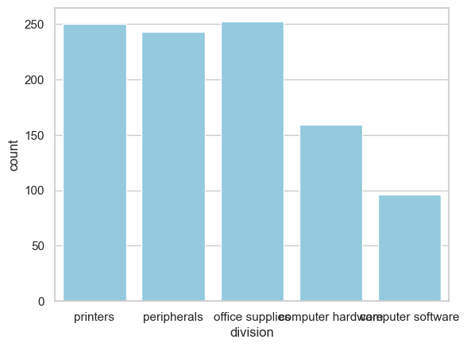

```python
sns.countplot(x="division", data=df, color='skyblue');
```

Для усунення накладення підписів можна використати налаштування `matplotlib`

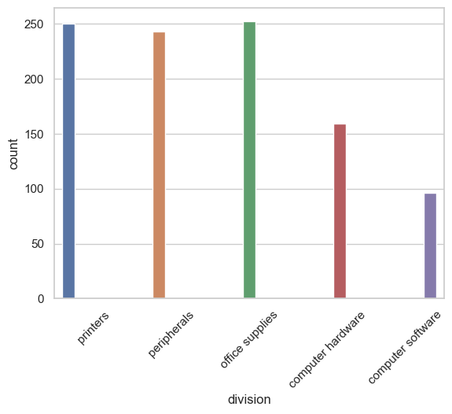

```python
plt.xticks(rotation=45); # обертаємо підписи на 45 градусів
sns.countplot(x="division", data=df, hue="division", dodge=True);
```

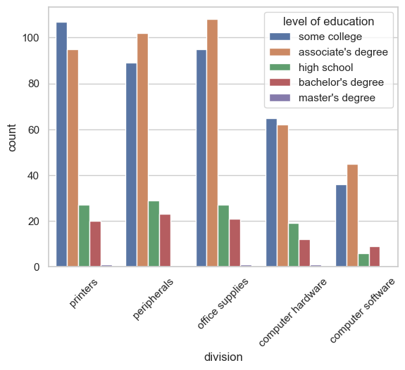

```python
# Параметр hue дозволяє відобразити дані за категоріями
plt.xticks(rotation=45); # обертаємо підписи на 45 градусів
sns.countplot(x="division", data=df, hue="level of education", dodge=True); # відображаємо графік
```

Для оцінювання агрегованих даних можна використати функцію `barplot`. При цьому, висота стовпця - середнє значення, тонка лінія - діапазон відхилення

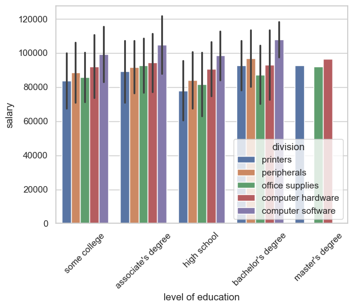

```python
plt.xticks(rotation=45); # обертаємо підписи на 45 градусів
sns.barplot(x="level of education", y="salary", data=df,
            errorbar='sd', estimator=np.mean, # оцінюємо середнє значення
            hue='division', dodge=True
            );
```

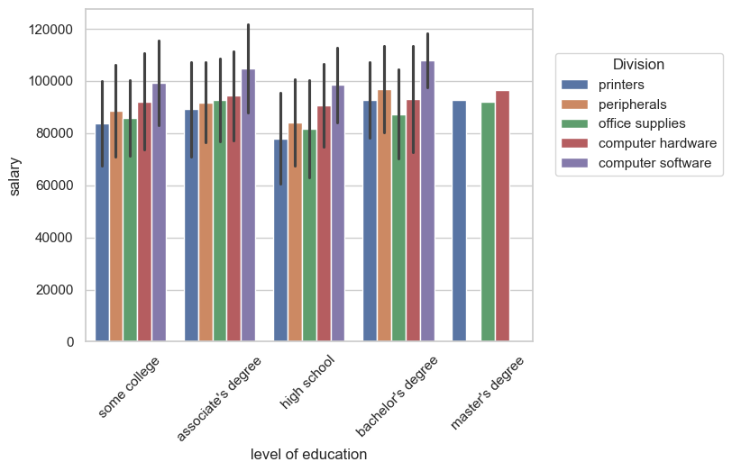

```python
# Щоб усунути накладення підписів можна використати налаштування matplotlib
plt.xticks(rotation=45); # обертаємо підписи на 45 градусів
sns.barplot(x="level of education", y="salary", data=df,
            errorbar='sd', estimator=np.mean, # оцінюємо середнє значення
            hue='division', dodge=True
            );
plt.legend(title='Division',loc=(1.05, 0.5)); # переміщуємо легенду
```

> *Практичне завдання 5*

> На основі наданої вибірки провести дослідження даних:
> 1. Побудувати графік `countplot()`.
> 2. Зробити висновки на основі аналізу даних.

#### 2.5 **heatmap**. Правила використання

При перегляді даних, які зведені у таблицю, іноді достатньо важко оцінити відхилення у значеннях за категоріями. Для цього використовують теплові карти `heatmap()`.

Файл для роботи з даними

```python
import seaborn as sns
import matplotlib.pyplot as plt
import pandas as pd
import numpy as np

df = pd.read_csv('country_table.csv')
df
```

|  | Countries | Birth rate | Mortality rate | Life expectancy | Infant mortality rate | Growth rate |
| --- | --- | --- | --- | --- | --- | --- |
| 0 | AFRICA | 32.577 | 7.837 | 63.472 | 44.215 | 24.40 |
| 1 | ASIA | 15.796 | 7.030 | 73.787 | 23.185 | 8.44 |
| 2 | EUROPE | 10.118 | 11.163 | 78.740 | 3.750 | 0.38 |
| 3 | LATIN AMERICA AND THE CARIBBEAN | 15.886 | 6.444 | 75.649 | 14.570 | 8.89 |
| 4 | NORTHERN AMERICA | 11.780 | 8.833 | 79.269 | 5.563 | 6.11 |
| 5 | OCEANIA | 16.235 | 6.788 | 78.880 | 16.939 | 12.79 |
| 6 | WORLD | 17.963 | 7.601 | 72.766 | 27.492 | 10.36 |

Дані відображені, але де є більші значення, тенденції не очевидно. Для цього у бібліотеці `seaborn` є функція, яка дозволяє побудувати теплову карту `heatmap()`.

Але перед цим необхідно підготувати дані, стовпець `Countries` є не числовим і крім того добре підходить для вибору його як індексу

```python
df = df.set_index('Countries')
df
```

| Countries | Birth rate | Mortality rate | Life expectancy | Infant mortality rate | Growth rate |
| --- | --- | --- | --- | --- | --- |
| AFRICA | 32.577 | 7.837 | 63.472 | 44.215 | 24.40 |
| ASIA | 15.796 | 7.030 | 73.787 | 23.185 | 8.44 |
| EUROPE | 10.118 | 11.163 | 78.740 | 3.750 | 0.38 |
| LATIN AMERICA AND THE CARIBBEAN | 15.886 | 6.444 | 75.649 | 14.570 | 8.89 |
| NORTHERN AMERICA | 11.780 | 8.833 | 79.269 | 5.563 | 6.11 |
| OCEANIA | 16.235 | 6.788 | 78.880 | 16.939 | 12.79 |
| WORLD | 17.963 | 7.601 | 72.766 | 27.492 | 10.36 |

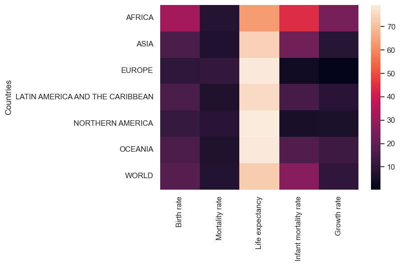

```python
sns.heatmap(data=df);
```

Оскільки в матриці багато значень, то можна використати параметр `annot` для відображення значень у клітинках

Для зміни кольору матриці можна використати параметр `cmap`

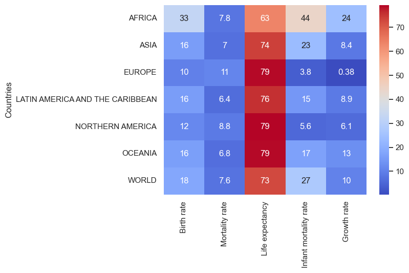

```python
sns.heatmap(data=df, annot=True, cmap='coolwarm');
```

Аналізуючи дані, можливо відмітити, що стовпець `Life expectancy` відрізняється числовим діапазоном. Тому цей стовпець доцільно виключити. Для цього використаємо відому вже функцію `.drop()`

axis=1 - вказує на необхідність видалення стовпця

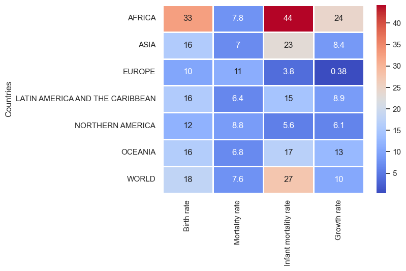

```python
sns.heatmap(data=df.drop('Life expectancy', axis=1),
            annot=True, linewidths=1,cmap='coolwarm');
```

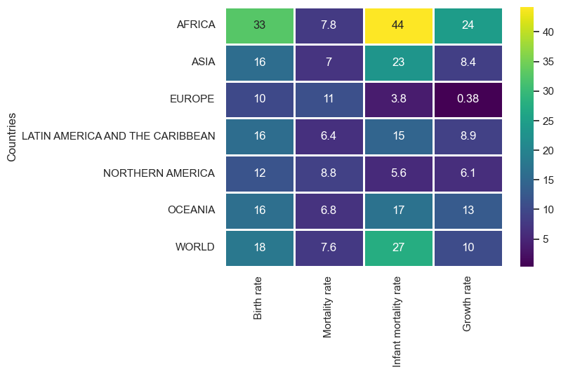

```python
sns.heatmap(data=df.drop('Life expectancy', axis=1),
            annot=True, linewidths=1,cmap='viridis');
```

Для здійснення групування між схожими рядками та стовпцями можна застосувати функцію `clustermap()`

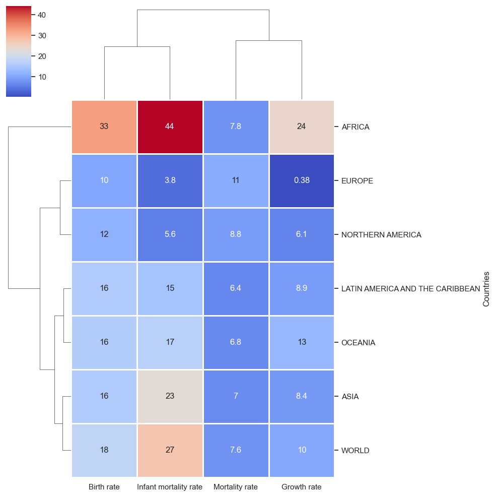

```python
sns.clustermap(data=df.drop('Life expectancy', axis=1), annot=True,
            linewidths=1,cmap='coolwarm');
```

> *Практичне завдання 6*

> На основі наданої вибірки провести дослідження даних:
> 1. Побудувати графік `heatmap()`.
> 2. Зробити висновки на основі аналізу даних.